# Tactile navigation

### Sart

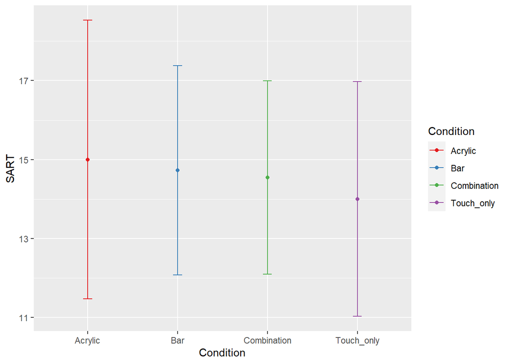

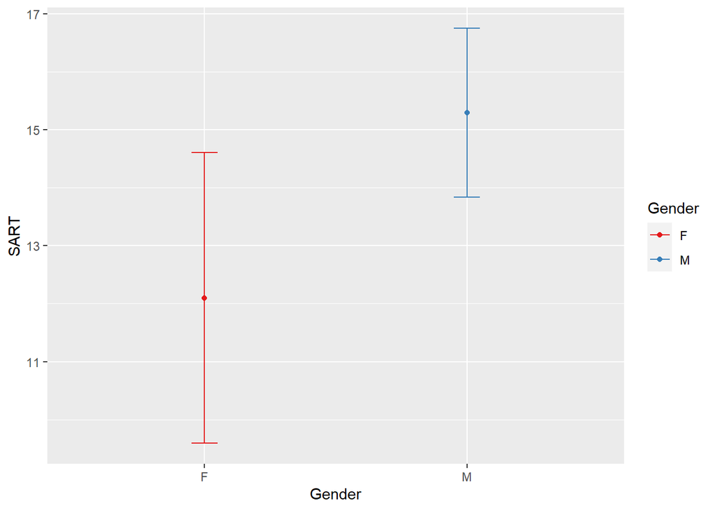

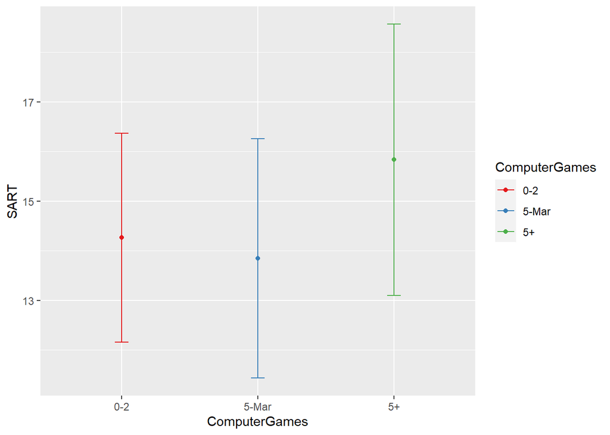

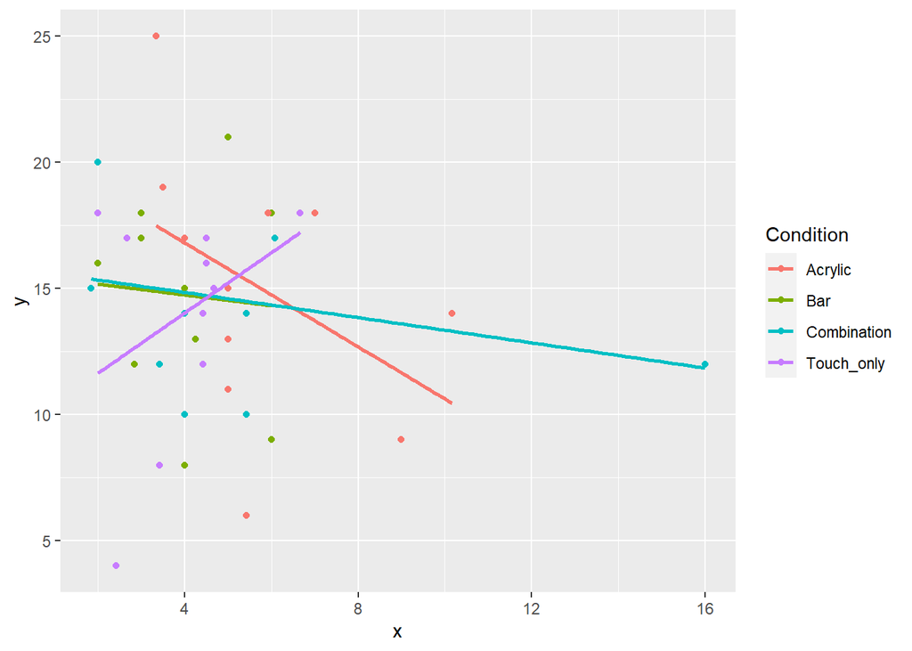

```
##
## [[5]]
##
## Call:
## lm(formula = y ~ x, data = dataFrame)
##
## Residuals:
##     Min      1Q  Median      3Q     Max
## -11.126  -2.709   0.331   2.755  10.092
##
## Coefficients:
##             Estimate Std. Error t value Pr(>|t|)
## (Intercept)  15.7029     1.4170  11.082 4.78e-14 ***
## x            -0.2386     0.2660  -0.897    0.375
## ---
## Signif. codes:  0 '***' 0.001 '**' 0.01 '*' 0.05 '.' 0.1 ' ' 1
##
## Residual standard error: 4.232 on 42 degrees of freedom
## Multiple R-squared:  0.01879,    Adjusted R-squared:  -0.004571
## F-statistic: 0.8044 on 1 and 42 DF,  p-value: 0.3749
##
##
## [[6]]
```

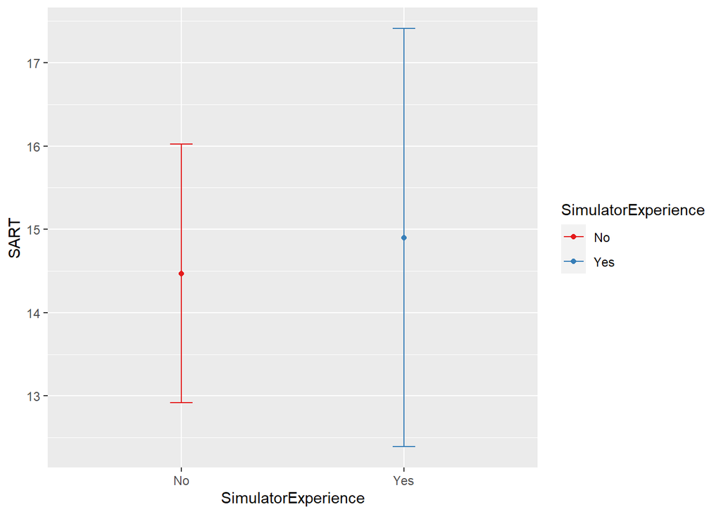

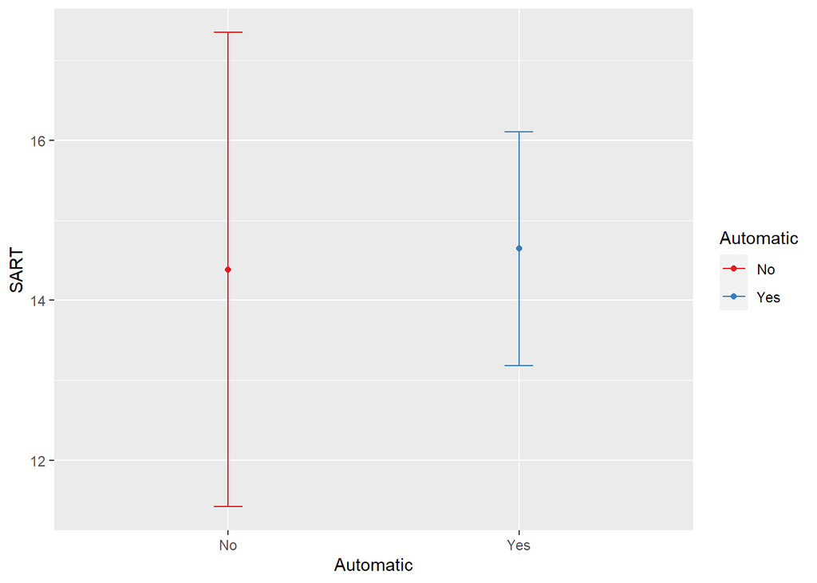

```r
SaveSixPlots("SART")
```

### Total crash

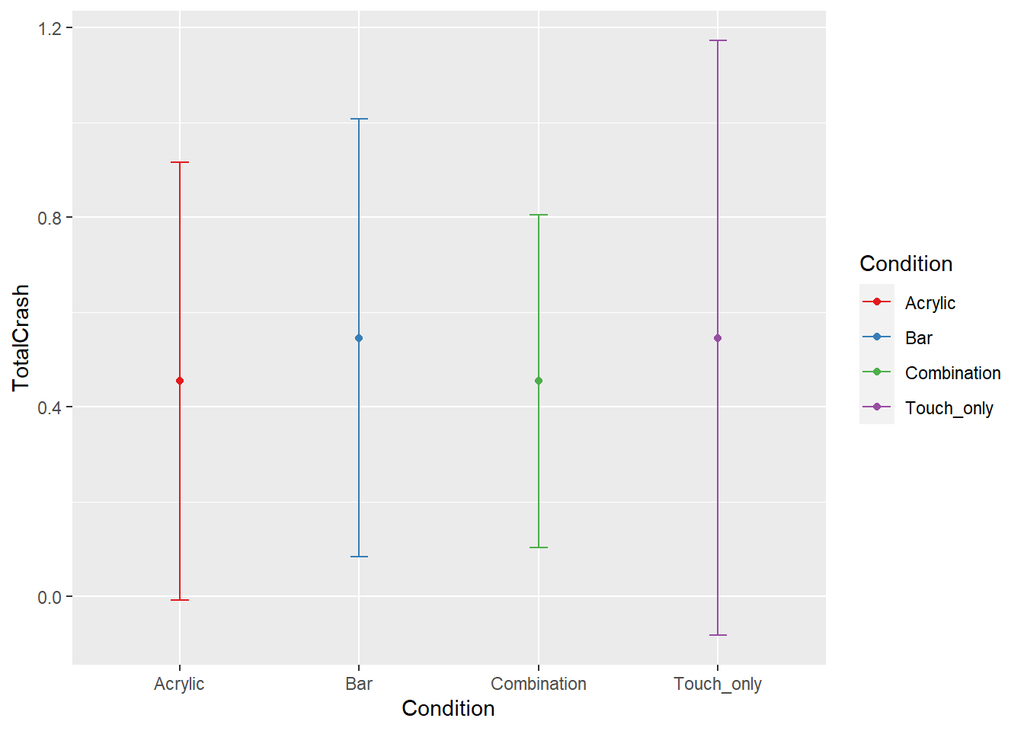

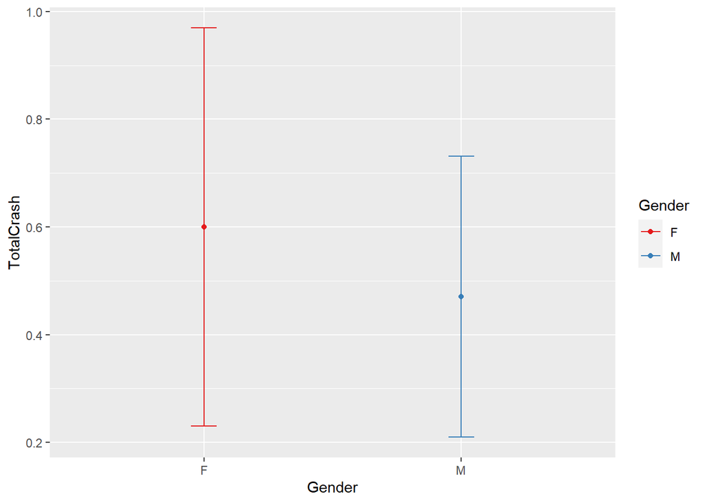

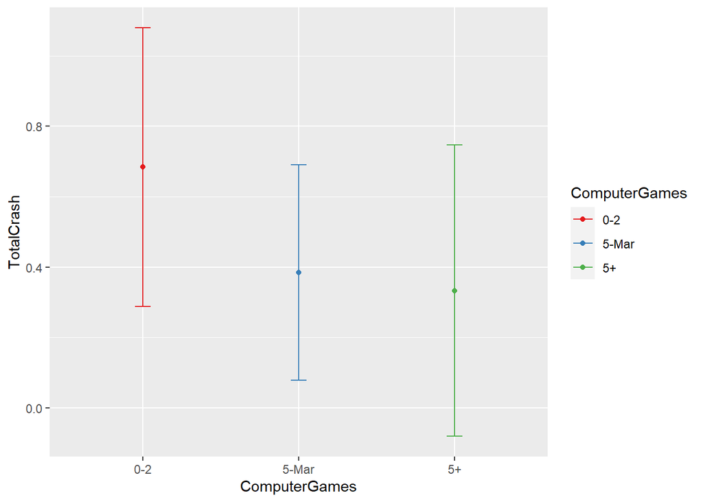

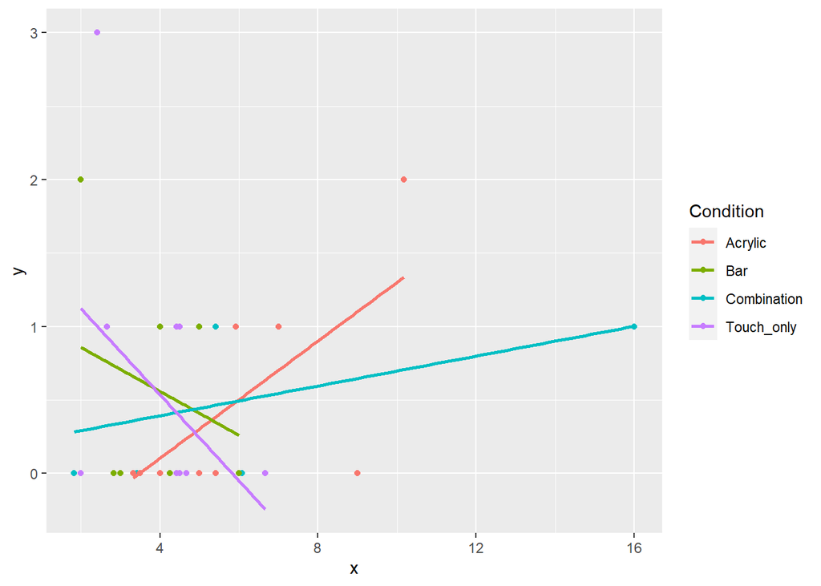

```
##
## [[5]]
##
## Call:
## lm(formula = y ~ x, data = dataFrame)
##
## Residuals:
##     Min      1Q  Median      3Q     Max
## -0.6321 -0.4933 -0.4428  0.4963  2.5728
##
## Coefficients:
##             Estimate Std. Error t value Pr(>|t|)
## (Intercept)  0.35204    0.23534   1.496    0.142
## x            0.03111    0.04419   0.704    0.485
##
## Residual standard error: 0.703 on 42 degrees of freedom
## Multiple R-squared:  0.01167,    Adjusted R-squared:  -0.01186
## F-statistic: 0.4958 on 1 and 42 DF,  p-value: 0.4852
##
##
## [[6]]
```

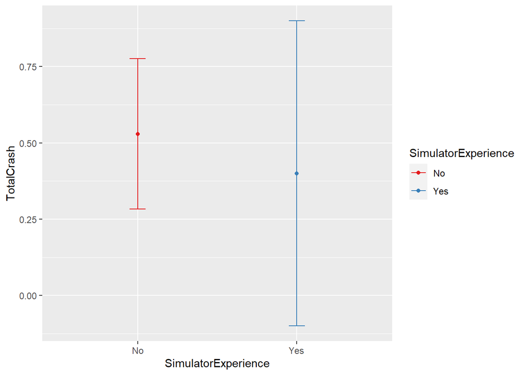

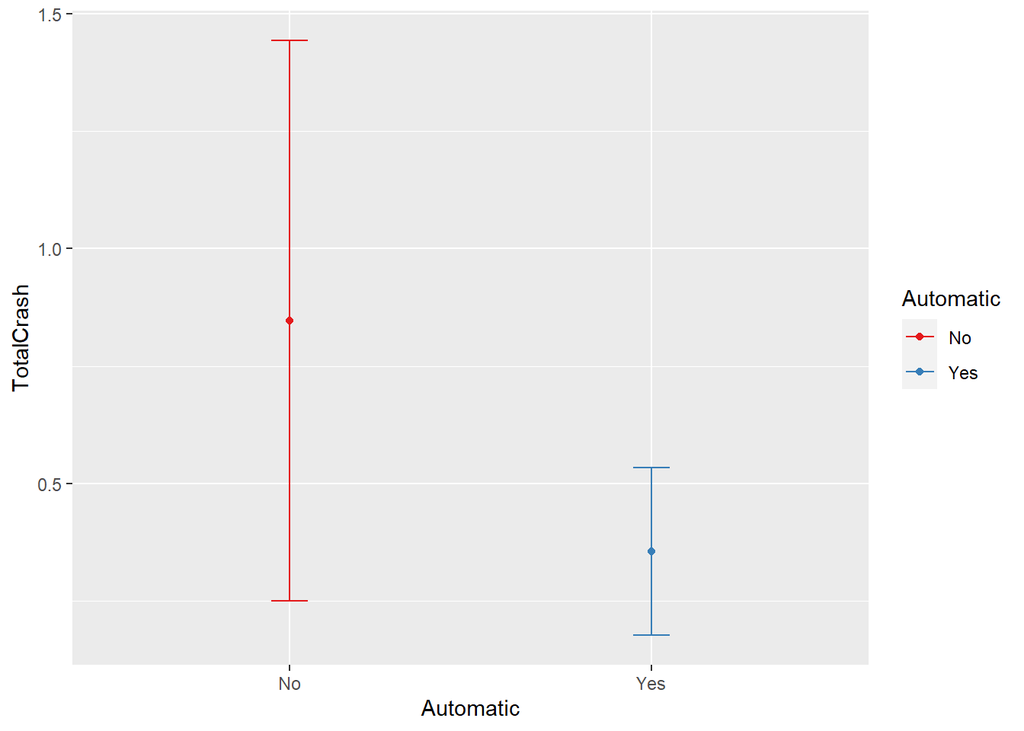

```r
SaveSixPlots("TotalCrash")
```

### Lane Breaks

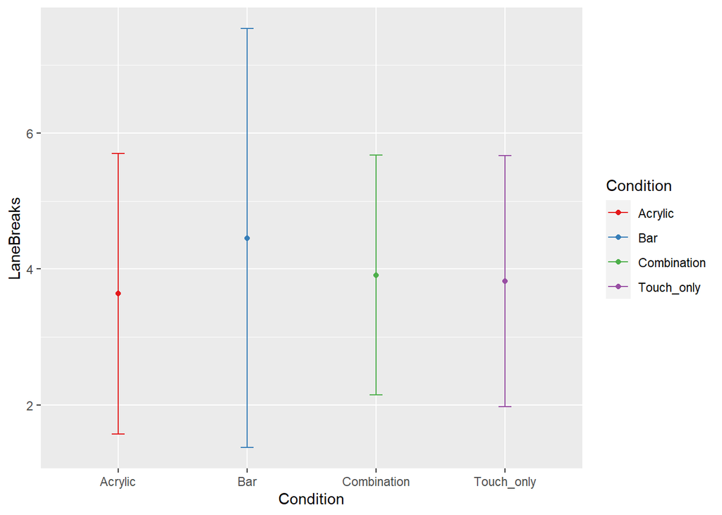

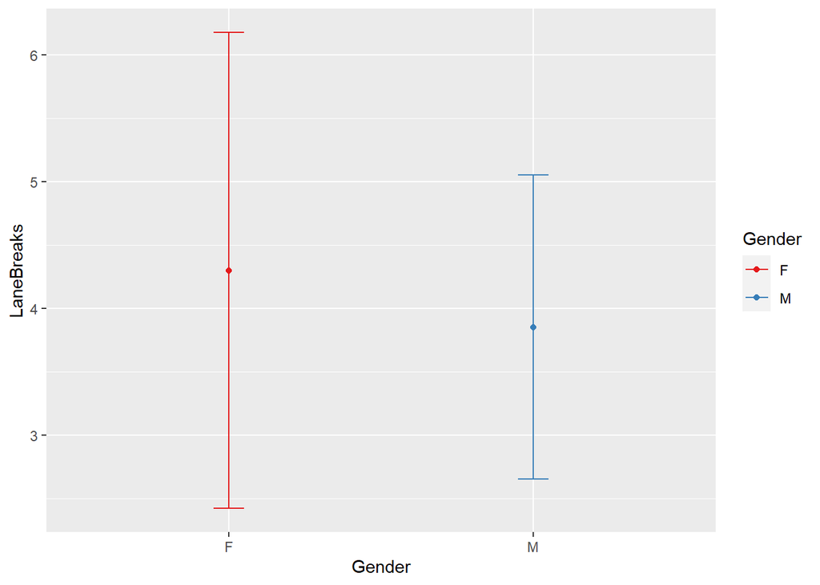

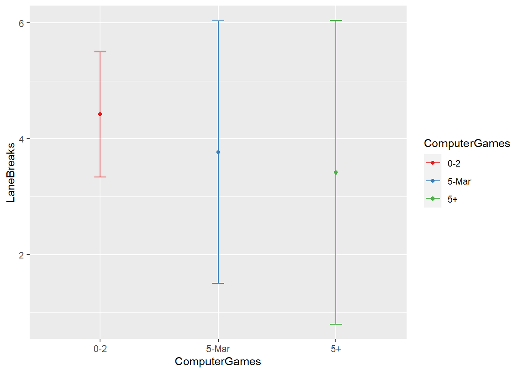

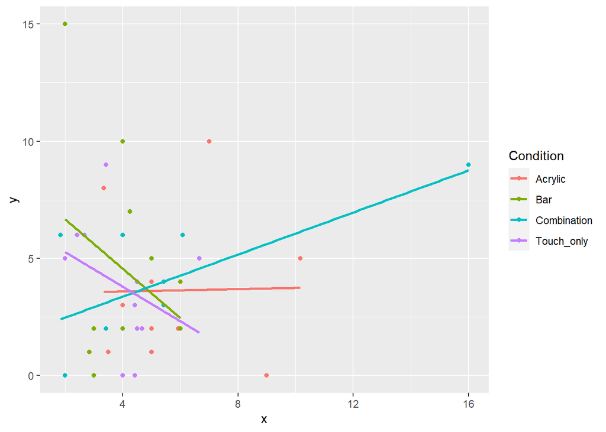

```
##
## [[5]]
##
## Call:
## lm(formula = y ~ x, data = dataFrame)
##
## Residuals:
##     Min      1Q  Median      3Q     Max
## -4.4578 -2.0947 -0.8649  1.9498 11.3722
##
## Coefficients:
##             Estimate Std. Error t value Pr(>|t|)
## (Intercept)   3.3907     1.0963   3.093  0.00352 **
## x             0.1186     0.2058   0.576  0.56764
## ---
## Signif. codes:  0 '***' 0.001 '**' 0.01 '*' 0.05 '.' 0.1 ' ' 1
##
## Residual standard error: 3.275 on 42 degrees of freedom
## Multiple R-squared:  0.007839,   Adjusted R-squared:  -0.01578
## F-statistic: 0.3319 on 1 and 42 DF,  p-value: 0.5676
##
##
## [[6]]
```

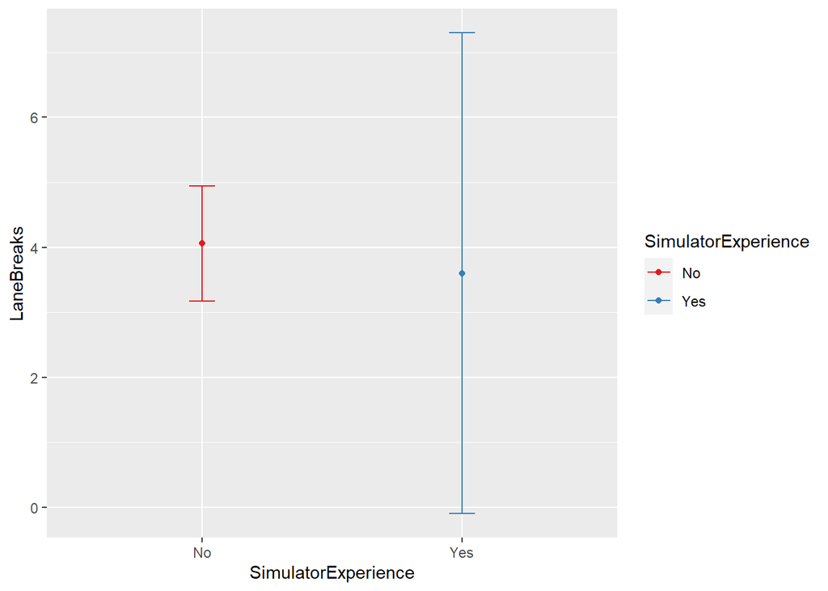

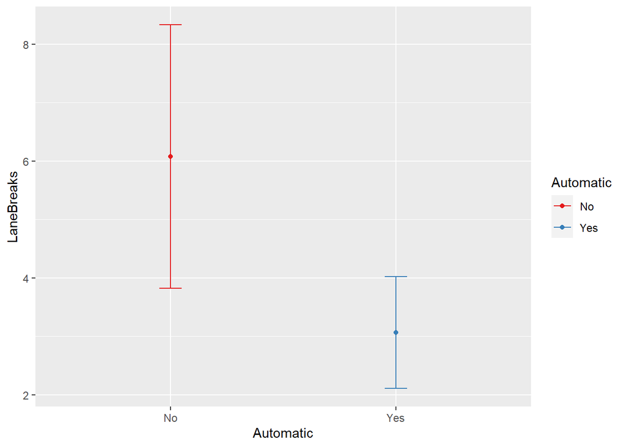

```r
SaveSixPlots("LaneBreaks")
```

### Total Glances

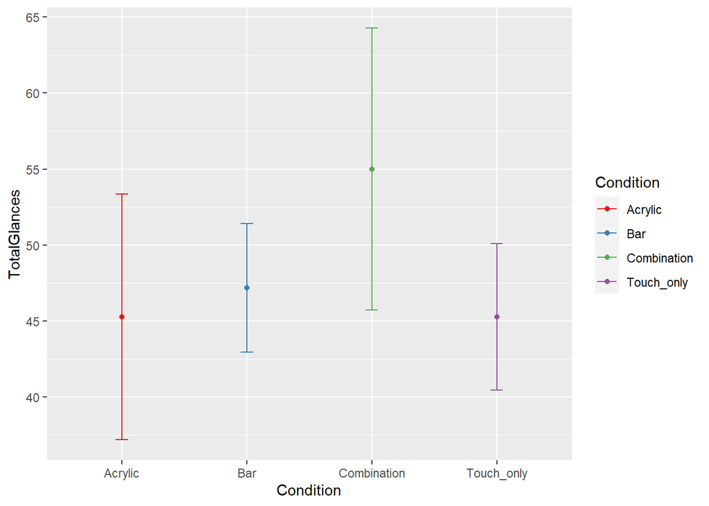

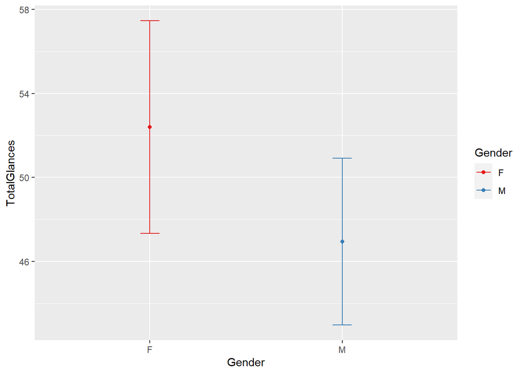

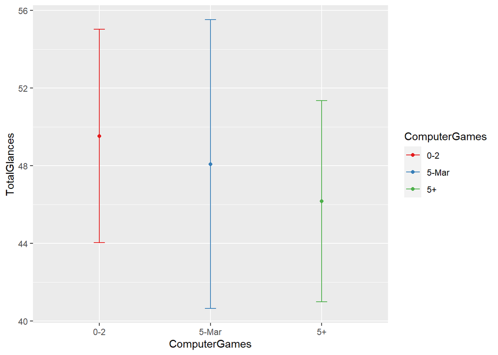

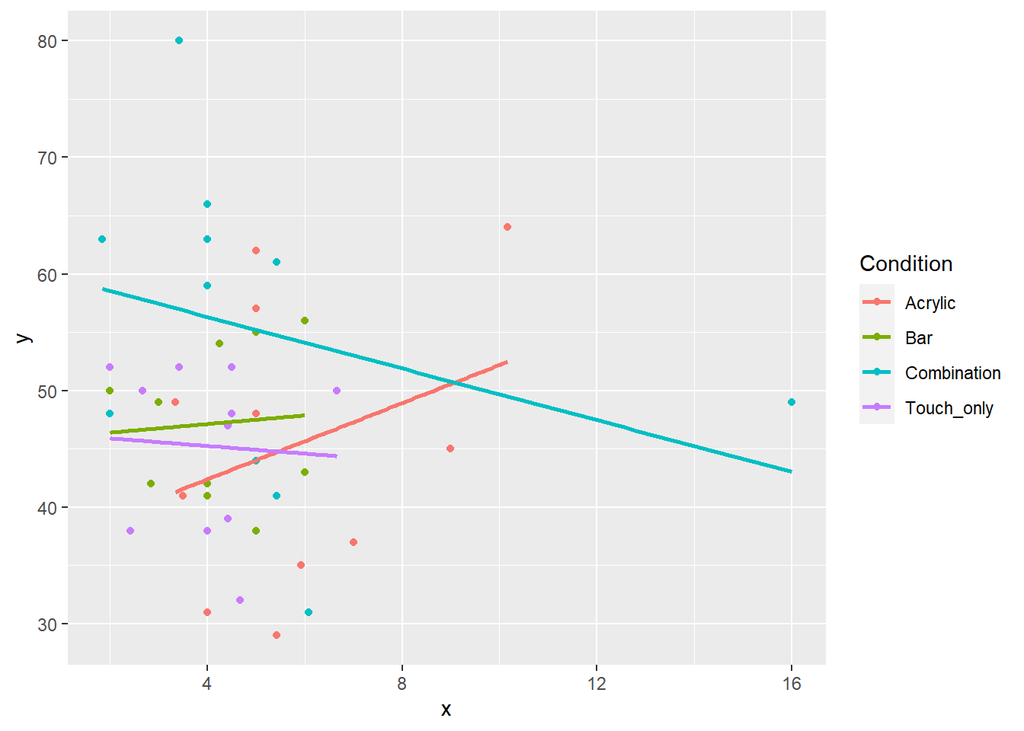

```
##
## [[5]]
##
## Call:
## lm(formula = y ~ x, data = dataFrame)
##
## Residuals:
##     Min      1Q  Median      3Q     Max
## -19.050  -7.358   0.167   6.005  31.550
##
## Coefficients:
##             Estimate Std. Error t value Pr(>|t|)
## (Intercept)  49.1331     3.6376  13.507   <2e-16 ***
## x            -0.2000     0.6829  -0.293    0.771
## ---
## Signif. codes:  0 '***' 0.001 '**' 0.01 '*' 0.05 '.' 0.1 ' ' 1
##
## Residual standard error: 10.87 on 42 degrees of freedom
## Multiple R-squared:  0.002038,   Adjusted R-squared:  -0.02172
## F-statistic: 0.08578 on 1 and 42 DF,  p-value: 0.7711
##
##
## [[6]]
```

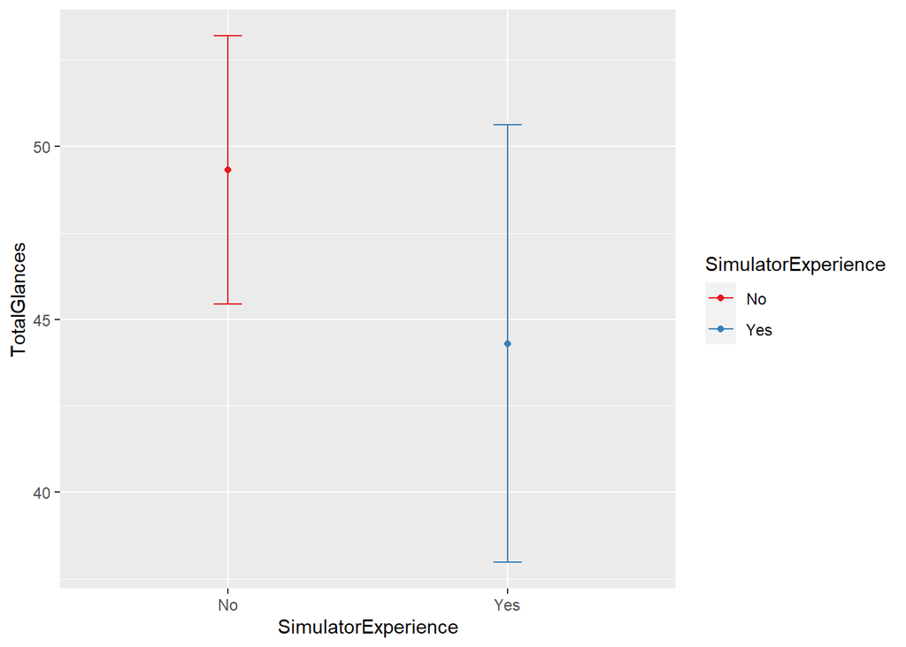

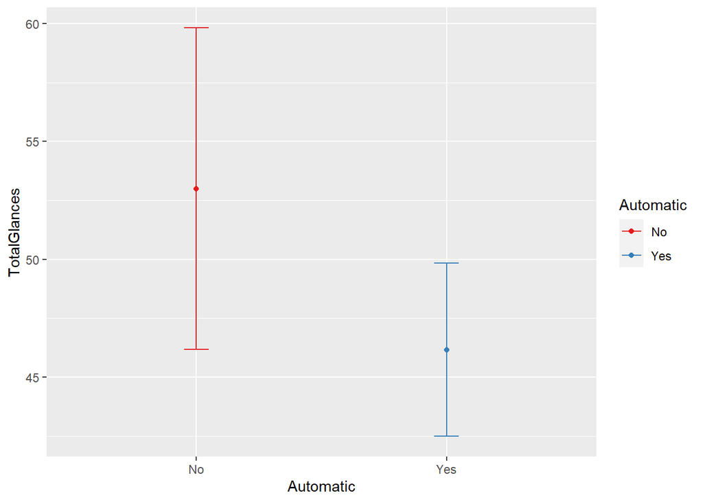

```r
SaveSixPlots("TotalGlances")
```

### Total Glance time

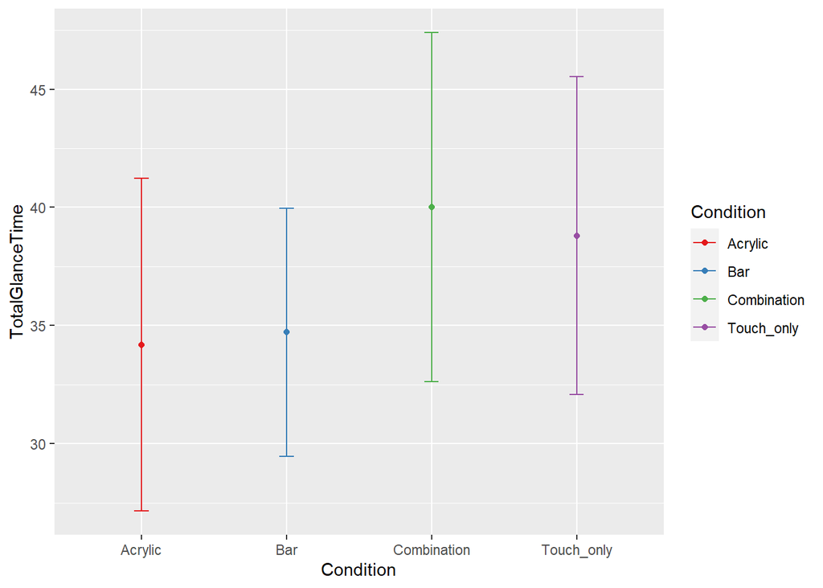

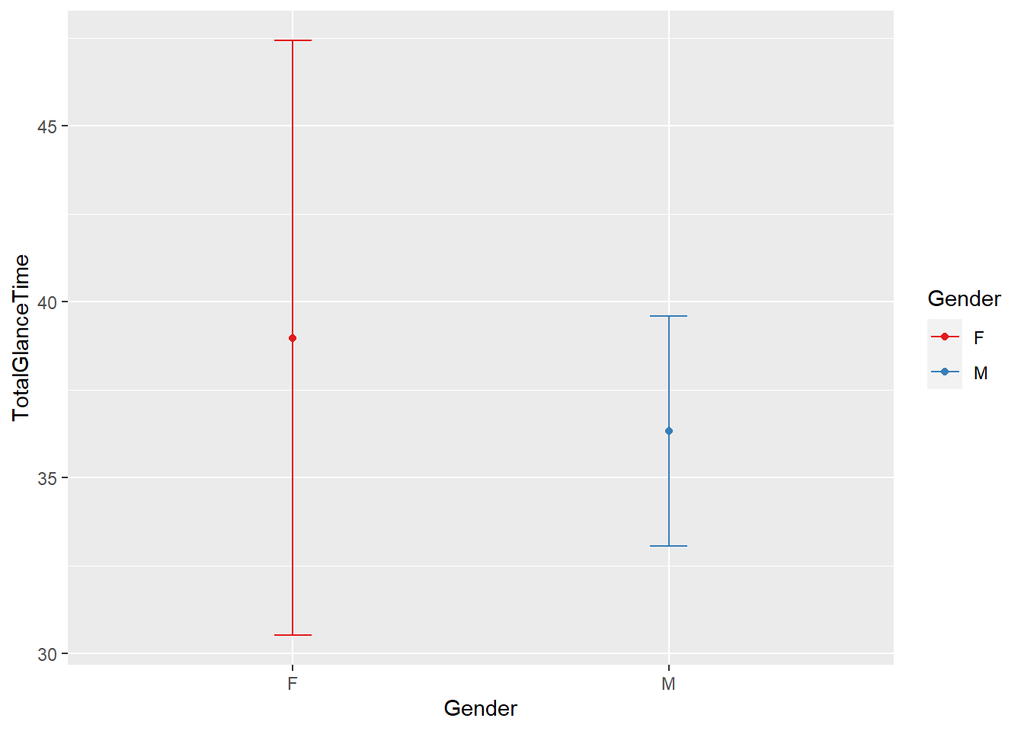

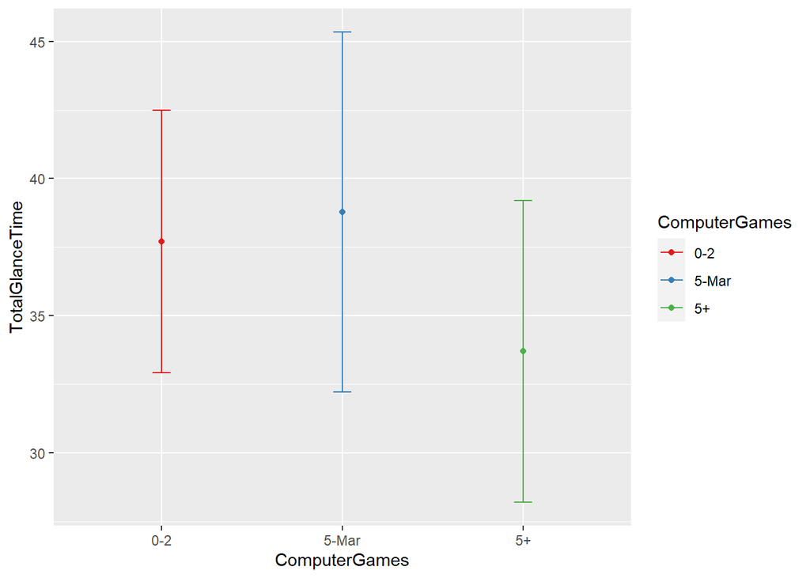

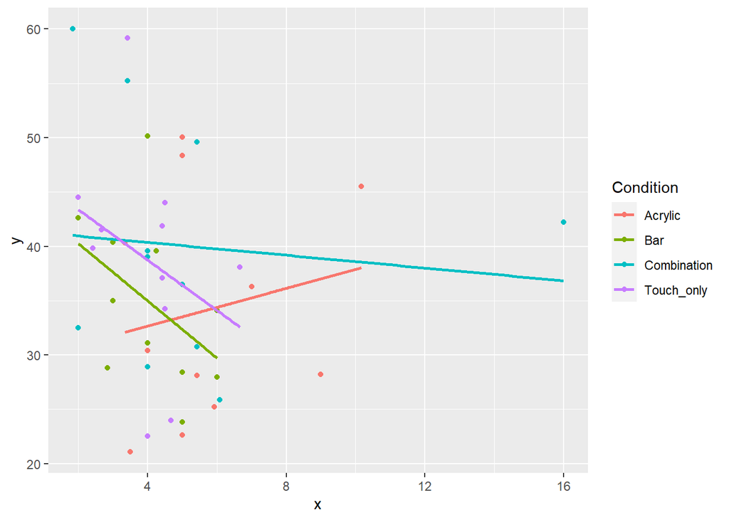

```
##
## [[5]]
##
## Call:
## lm(formula = y ~ x, data = dataFrame)
##
## Residuals:
##      Min       1Q   Median       3Q      Max
## -16.3769  -8.3684   0.1266   5.2345  21.8988
##
## Coefficients:
##             Estimate Std. Error t value Pr(>|t|)
## (Intercept)  38.8529     3.3289  11.671 9.15e-15 ***
## x            -0.4046     0.6250  -0.647    0.521
## ---
## Signif. codes:  0 '***' 0.001 '**' 0.01 '*' 0.05 '.' 0.1 ' ' 1
##
## Residual standard error: 9.944 on 42 degrees of freedom
## Multiple R-squared:  0.009878,   Adjusted R-squared:  -0.0137
## F-statistic: 0.419 on 1 and 42 DF,  p-value: 0.5209
##
##
## [[6]]
```

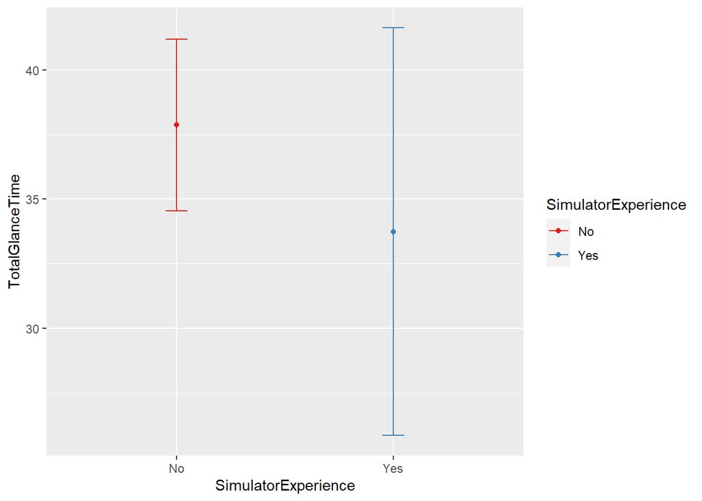

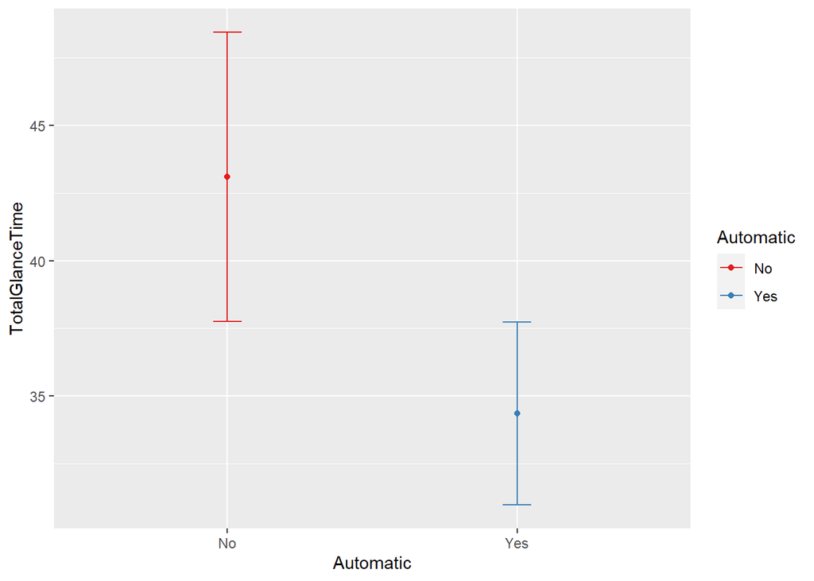

## From the many plot of means with confidence interval 95% as wisksers we’ve determined to test the following interactions

```r
LaneBreaksAutomatic <- t.test(formula = LaneBreaks ~ Automatic, data = dataFrame)
SartGender <- t.test(formula = SART ~ Gender, data = dataFrame)
CrashComputer <- kruskal.test(formula = TotalCrash ~ ComputerGames, data = dataFrame)
CrashAutomatic <- t.test(formula = TotalCrash ~ Automatic, data = dataFrame)
GlanceTimeAutomatic <- t.test(formula = TotalGlanceTime ~ Automatic, data = dataFrame)
GlancesGender <- t.test(formula = TotalGlances ~ Gender, data = dataFrame)
GlancesAutomatic <- t.test(formula = TotalGlances ~ Automatic, data = dataFrame)

# Måske er der noget med glances og condition

LaneBreaksAutomatic
```

```
##
##  Welch Two Sample t-test
##
## data:  LaneBreaks by Automatic
## t = 2.6531, df = 17.133, p-value = 0.01666
## alternative hypothesis: true difference in means between group No and group Yes is not equal to 0
## 95 percent confidence interval:
##  0.618242 5.406572
## sample estimates:
##  mean in group No mean in group Yes
##          6.076923          3.064516
```

```r
SartGender
```

```
##
##  Welch Two Sample t-test
##
## data:  SART by Gender
## t = -2.4169, df = 17.261, p-value = 0.02699
## alternative hypothesis: true difference in means between group F and group M is not equal to 0
## 95 percent confidence interval:
##  -5.9791715 -0.4090638
## sample estimates:
## mean in group F mean in group M
##        12.10000        15.29412
```

```r
CrashComputer
```

```
##
##  Kruskal-Wallis rank sum test
##
## data:  TotalCrash by ComputerGames
## Kruskal-Wallis chi-squared = 2.2623, df = 2, p-value = 0.3227
```

```r
CrashAutomatic
```

```
##
##  Welch Two Sample t-test
##
## data:  TotalCrash by Automatic
## t = 1.7097, df = 14.508, p-value = 0.1086
## alternative hypothesis: true difference in means between group No and group Yes is not equal to 0
## 95 percent confidence interval:
##  -0.1230151  1.1056453
## sample estimates:
##  mean in group No mean in group Yes
##         0.8461538         0.3548387
```

```r
GlanceTimeAutomatic
```

```
##
##  Welch Two Sample t-test
##
## data:  TotalGlanceTime by Automatic
## t = 2.953, df = 23.453, p-value = 0.007043
## alternative hypothesis: true difference in means between group No and group Yes is not equal to 0
## 95 percent confidence interval:
##   2.626666 14.871746
## sample estimates:
##  mean in group No mean in group Yes
##          43.09308          34.34387
```

```r
GlancesGender
```

```
##
##  Welch Two Sample t-test
##
## data:  TotalGlances by Gender
## t = 1.8374, df = 24.153, p-value = 0.07848
## alternative hypothesis: true difference in means between group F and group M is not equal to 0
## 95 percent confidence interval:
##  -0.6707051 11.5883521
## sample estimates:
## mean in group F mean in group M
##        52.40000        46.94118
```

```r
GlancesAutomatic
```

```
##
##  Welch Two Sample t-test
##
## data:  TotalGlances by Automatic
## t = 1.8943, df = 20.358, p-value = 0.07249
## alternative hypothesis: true difference in means between group No and group Yes is not equal to 0
## 95 percent confidence interval:
##  -0.6836275 14.3610468
## sample estimates:
##  mean in group No mean in group Yes
##          53.00000          46.16129
```

When analysing this much data the risk of p-hacking increases. We’ll only use these significanses if there is a big heteroscedasticity in regards to the four conditions maybe this change can explain

The three significant effects were:  
1) LaneBreaks by Automatic 0.01666  
2) TotalGlanceTime by Automatic 0.007043  
3) SART by Gender 0.02699

We’ll see if these effects have been equally distributed across the four conditions:

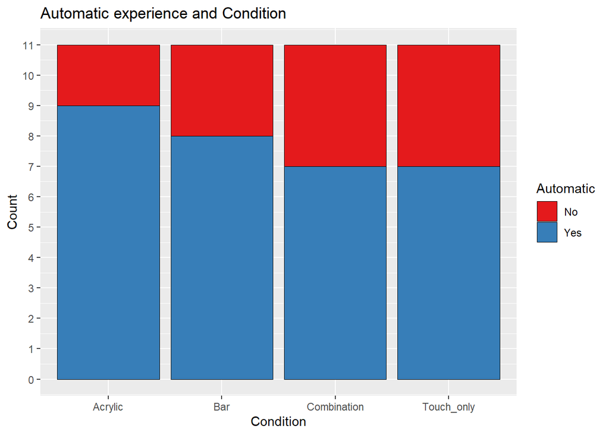

```r
AutomaticExperienceCondition
```

Automatic experience is distributed quite nice with a difference of 2 between highest and lowest. Therefore this effect is irrelevant.

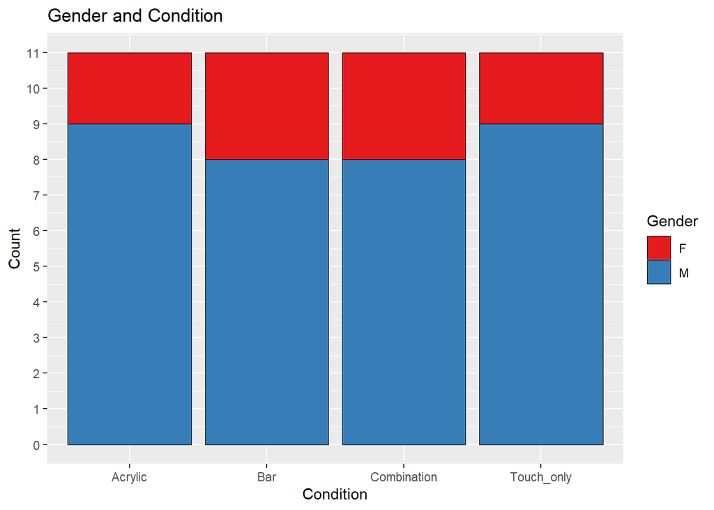

```r
GenderCondition
```

Gender is distributed with a difference of 1 between highest and lowest. Therefore this effect is irrelevant

To test significance we will use ANOVA  
ANOVA has Three assumptions  
1) Normality  
2) Homogenity  
3) Independence  
The assumption of Independence is meet as our participants haven’t influence each other in any way we know of. The participants were instructed not to speak with each other between trials and we can hope they have met this instruction.

### Analysis of glance duration per task

Another interesting aspect to look at is the distribution of glance duration across all tasks. This could potentially reveal patterns in certain tasks taking longer on average, indicating an imbalance in difficulty among the tasks

The glance durations are analysed with regards to guidelines found for IVIS designs - a single glance should be shorter than 1.5 seconds - the total time with eyes off the road should be less than 12 seconds for each task

```r
percentTooLongGlances <- (sum(taskLongDataFrame$Single_Glance_duration >= 1.5) / sum(taskLongDataFrame$Single_Glance_duration > 0)) * 100
percentTooLongGlances
```

```
## [1] 5.09434
```

```r
percentTooLongTasks <- (sum(taskShortDataFrame$Total_glance_duration_pr_task >= 12) / sum(taskShortDataFrame$Total_glance_duration_pr_task > 0)) * 100
percentTooLongTasks
```

```
## [1] 2.283105
```

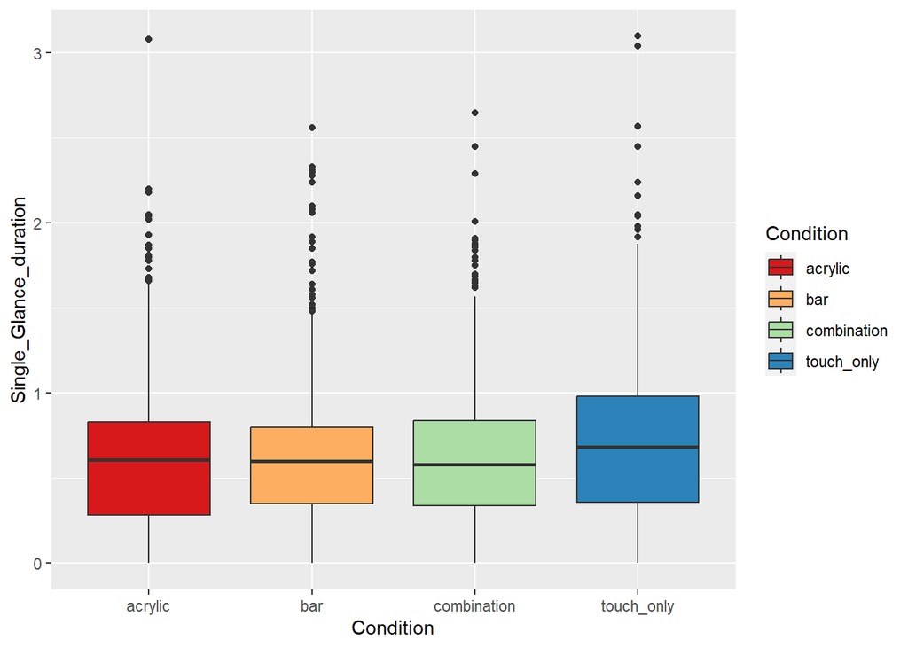

```r
singleGlanceBox <- ggplot(taskLongDataFrame, aes(x = Condition, y = Single_Glance_duration, fill = Condition)) +
    geom_boxplot() +
    scale_fill_brewer(palette = "Spectral")
singleGlanceBox
```

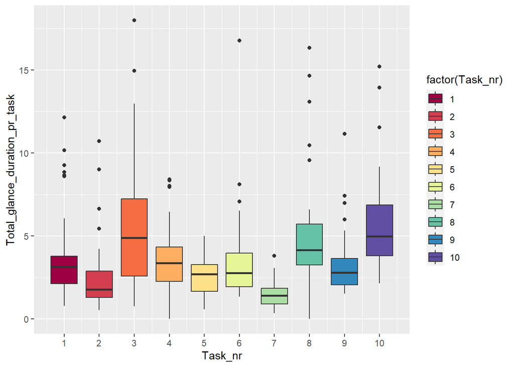

```r
glanceTaskBox <- ggplot(taskShortDataFrame, aes(x = Task_nr, y = Total_glance_duration_pr_task, group = Task_nr, fill = factor(Task_nr))) +
    geom_boxplot() +
    scale_x_continuous(breaks = seq(0, 10, by = 1)) +
    scale_fill_brewer(palette = "Spectral")
glanceTaskBox
```